# Associational and Inferential Techniques

Steven V. Miller, svmiller.com

28 January 2021

Abstract

This is a lab script for [POST 8000](http://post8000.svmiller.com), a graduate-level quantitative methods for public policy class that I teach at Clemson University. It will not be the most sophisticated R-related write-up of mine—check [my blog](http://svmiller.com/blog) for those—but it should be useful for discussion around the associated R script for the week’s ‘lab’ session.

# Elsewhere on My Website

Some of what I write here is taken from my website. Please read these:

- [Illustrate Some Correlation Limitations and Fallacies in R](http://svmiller.com/blog/2020/01/illustrate-correlation-fallacies-limitations-in-r/)
- [The Normal Distribution, Central Limit Theorem, and Inference from a Sample](http://svmiller.com/blog/2020/03/normal-distribution-central-limit-theorem-inference/)

Be advised I might plagiarize myself here.

# R Packages/Data for This Session

You should’ve already installed two of the following R packages for this lab session. `{tidyverse}` will be for all things workflow and `{stevedata}` will be for the toy data sets. Let’s load those libraries now. The order doesn’t really matter here. I think I had mistaken that `{broom}` was in `{tidyverse}` and it does not appear to be. No matter It’s a wonderful package for a lot of things—probably one of the best value-added packages in all of R. Install it if you have not.

The following thing below is something I wrote for the IPSA-FLACSO program in Mexico City in 2019—and, sidebar, I miss the hell out of that amazing city and FLACSO should invite me back for things. Basically, this thing looks for whether you have downloaded/installed a package from CRAN and, if you don’t have it, it installs it.

```r
pack <- c("broom")
new_pack <- pack[!(pack %in% installed.packages()[,"Package"])]
if(length(new_pack)) install.packages(new_pack)
```

Let’s load what we’ll be using here.

```r
library(tidyverse)
library(stevedata)
library(broom)
```

# Correlation

Let’s start with an illustration of basic correlation. There are any number of ways of doing a rudimentary correlation in R, but it’s worth noting that the `cor()` function comes standard in R. However, like the `mean()`, `median()` and `sd()` functions, you’ll need to be mindful of NAs in your data. If you have them, you’ll want to add use = “complete.obs” as an extra parameter in `cor()`.

Let’s do something simple. Let’s correlate the `sumnatsoc` measure (which increases as the respondent believes we’re spending too little on various social programs) with the respondent’s ideology. As always, check `?gss_spending` for more clarity about the measure.

```r
cor(gss_spending$polviews, gss_spending$sumnatsoc, use="complete.obs")
```

```
## [1] -0.3510539
```

This will tell you the Pearon’s *r* (correlation coefficient) between both is -.35, which is a decently strong negative correlation. Be mindful of a few things with correlation. While there is such a thing as a correlation test for significance (which I’ll talk a little bit about for instrumental variables later in the semester), most assessments of correlation beyond -1, 0, or 1 are informal. Notice the awkwardness of “decently strong negative” correlation. To be clear, the correlation is negative, but the strength of it and how you summarize it is a “use your head” issue here.

Further, and recall, correlation is ambivalent about what is *x* and what is *y*. You can flip the two and get the exact same Pearon’s *r* back.

```r
cor(gss_spending$sumnatsoc, gss_spending$polviews, use="complete.obs")
```

```
## [1] -0.3510539
```

But, if you’re going to just explore without overwriting anything, you can add it to a pipe workflow. Observe:

```r
gss_spending %>%
  summarize(r = cor(polviews, sumnatsoc, use="complete.obs"))
```

```
## # A tibble: 1 x 1
##        r
##    <dbl>
## 1 -0.351
```

I end up doing it this way since it’s less code. `{tidyverse}` for the win.

Correlation is super useful as preliminary exploratory data analysis, and for checking for multicollinearity concerns. But be mindful. Correlation may mislead you. Let’s start with Anscombe’s quartets.

## Anscombe’s Quartets

Francis J. Anscombe’s (1973) famous quartet is a go-to illustration for how simple associational analyses, even linear regression, can mislead the researcher if s/he is not taking care to actually look at the underlying data. Here, Anscombe created four data sets, each with 11 observations and two variables (x and y). All four quartets have the same mean for x and y, the same variance for x and y, the same regression line (y-intercept and slope for x), the same residual sum of squares, and the same correlation. However, they look quite differently.

Let’s look at the data first.

```r
?quartets
quartets
```

```
## # A tibble: 44 x 3
##        x     y group
##    <dbl> <dbl> <chr>
##  1    10  8.04 Quartet 1
##  2     8  6.95 Quartet 1
##  3    13  7.58 Quartet 1
##  4     9  8.81 Quartet 1
##  5    11  8.33 Quartet 1
##  6    14  9.96 Quartet 1
##  7     6  7.24 Quartet 1
##  8     4  4.26 Quartet 1
##  9    12 10.8  Quartet 1
## 10     7  4.82 Quartet 1
## # … with 34 more rows
```

Notice these four quartets each have the same mean and standard deviation for x and y.

```r
quartets %>%
  group_by(group) %>%
  summarize_if(is.numeric, list(mean = mean, sd = sd))
```

```
## # A tibble: 4 x 5
##   group     x_mean y_mean  x_sd  y_sd
##   <chr>      <dbl>  <dbl> <dbl> <dbl>
## 1 Quartet 1      9   7.50  3.32  2.03
## 2 Quartet 2      9   7.50  3.32  2.03
## 3 Quartet 3      9   7.5   3.32  2.03
## 4 Quartet 4      9   7.50  3.32  2.03
```

The correlations are effectively the same for all four quartets.

```r
quartets %>%
  group_by(group) %>%
  summarize(r = cor(x, y))
```

```
## # A tibble: 4 x 2
##   group         r
##   <chr>     <dbl>
## 1 Quartet 1 0.816
## 2 Quartet 2 0.816
## 3 Quartet 3 0.816
## 4 Quartet 4 0.817
```

The linear function of y ~ x is practically the same across all four quartets. This is where I asked to download the `{broom}` package. I’ll annotate this a little bit to make it clearer.

```r
quartets %>%
  # nest the data under the particular group
  nest(data = -group) %>%
  # Then, using {purrr} `map()` magic, do a linear regression on each group.
  # Then, using {broom}'s `tidy()` magic to gank the results into a table
  mutate(fit = map(data, ~lm(y ~ x, data=.)),
         tidied = map(fit, broom::tidy)) %>%
  # unnest the table to show us what we want.
  unnest(tidied) %>%
  # select just what we want to see.
  select(group, term:p.value)
```

```
## # A tibble: 8 x 6
##   group     term        estimate std.error statistic p.value
##   <chr>     <chr>          <dbl>     <dbl>     <dbl>   <dbl>
## 1 Quartet 1 (Intercept)    3.00      1.12       2.67 0.0257
## 2 Quartet 1 x              0.500     0.118      4.24 0.00217
## 3 Quartet 2 (Intercept)    3.00      1.13       2.67 0.0258
## 4 Quartet 2 x              0.5       0.118      4.24 0.00218
## 5 Quartet 3 (Intercept)    3.00      1.12       2.67 0.0256
## 6 Quartet 3 x              0.500     0.118      4.24 0.00218
## 7 Quartet 4 (Intercept)    3.00      1.12       2.67 0.0256
## 8 Quartet 4 x              0.500     0.118      4.24 0.00216
```

However, each quartet looks quite different.

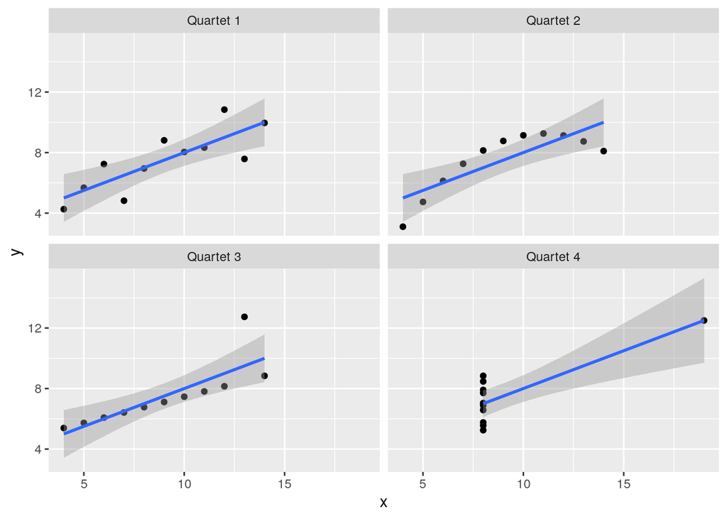

```r
quartets %>%
  ggplot(.,aes(x,y)) +
  facet_wrap(~group) + geom_point() + geom_smooth(method = "lm")
```

Basically: look at your data and be mindful that you can be easily misled if you don’t do this.

## The Datasaurus

If you want a more extreme example of the same basic thing, check out the `Datasaurus` data in `{stevedata}`.

```r
?Datasaurus
Datasaurus
```

```
## # A tibble: 1,846 x 3
##    dataset     x     y
##    <chr>   <dbl> <dbl>
##  1 dino     55.4  97.2
##  2 dino     51.5  96.0
##  3 dino     46.2  94.5
##  4 dino     42.8  91.4
##  5 dino     40.8  88.3
##  6 dino     38.7  84.9
##  7 dino     35.6  79.9
##  8 dino     33.1  77.6
##  9 dino     29.0  74.5
## 10 dino     26.2  71.4
## # … with 1,836 more rows
```

Basically, the people who wrote these data rightly complained that Anscombe wasn’t 100% transparent with how he created the data he did. Plus, you can have more fun with these data. Note that the descriptive stats here are basically identical.

```r
Datasaurus %>%
  group_by(dataset) %>%
  summarize(x_bar = mean(x),
            x_sd = sd(x),
            y_bar = mean(y),
            y_sd = sd(y),
            cor = cor(x, y))
```

```
## # A tibble: 13 x 6
##    dataset    x_bar  x_sd y_bar  y_sd     cor
##    <chr>      <dbl> <dbl> <dbl> <dbl>   <dbl>
##  1 away        54.3  16.8  47.8  26.9 -0.0641
##  2 bullseye    54.3  16.8  47.8  26.9 -0.0686
##  3 circle      54.3  16.8  47.8  26.9 -0.0683
##  4 dino        54.3  16.8  47.8  26.9 -0.0645
##  5 dots        54.3  16.8  47.8  26.9 -0.0603
##  6 h_lines     54.3  16.8  47.8  26.9 -0.0617
##  7 high_lines  54.3  16.8  47.8  26.9 -0.0685
##  8 slant_down  54.3  16.8  47.8  26.9 -0.0690
##  9 slant_up    54.3  16.8  47.8  26.9 -0.0686
## 10 star        54.3  16.8  47.8  26.9 -0.0630
## 11 v_lines     54.3  16.8  47.8  26.9 -0.0694
## 12 wide_lines  54.3  16.8  47.8  26.9 -0.0666
## 13 x_shape     54.3  16.8  47.8  26.9 -0.0656
```

The regression line is basically the same.

```r
Datasaurus %>%
  nest(data = -dataset) %>%
  mutate(fit = map(data, ~lm(y ~ x, data=.)),
         tidied = map(fit, broom::tidy)) %>%
  # unnest the table to show us what we want.
  unnest(tidied) %>%
  # select just what we want to see.
  select(dataset, term:p.value)
```

```
## # A tibble: 26 x 6
##    dataset term        estimate std.error statistic  p.value
##    <chr>   <chr>          <dbl>     <dbl>     <dbl>    <dbl>
##  1 dino    (Intercept)  53.5        7.69      6.95  1.29e-10
##  2 dino    x            -0.104      0.136    -0.764 4.46e- 1
##  3 away    (Intercept)  53.4        7.69      6.94  1.31e-10
##  4 away    x            -0.103      0.135    -0.760 4.48e- 1
##  5 h_lines (Intercept)  53.2        7.70      6.91  1.53e-10
##  6 h_lines x            -0.0992     0.136    -0.732 4.66e- 1
##  7 v_lines (Intercept)  53.9        7.69      7.01  9.38e-11
##  8 v_lines x            -0.112      0.135    -0.824 4.12e- 1
##  9 x_shape (Intercept)  53.6        7.69      6.97  1.17e-10
## 10 x_shape x            -0.105      0.135    -0.778 4.38e- 1
## # … with 16 more rows
```

But the data look quite different.

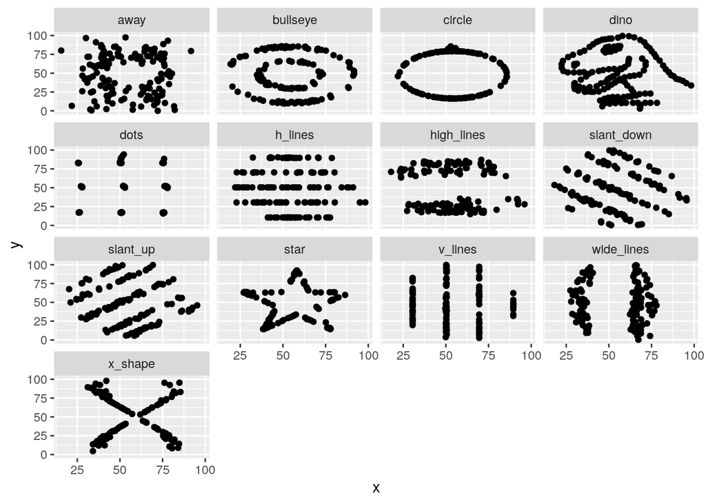

```r
Datasaurus %>%
  ggplot(.,aes(x, y)) + geom_point() +
  facet_wrap(~dataset)
```

Always look at your data. Roar.

## Simpson’s Paradox

Simpson’s paradox is a well-known problem of correlation in which a correlation analysis, almost always done in a bivariate context, may reveal a relationship that is reversed upon the introduction of some third variable. Every stylized case I’ve seen of Simpson’s paradox conceptualizes the third factor as some kind of grouping/category effect (certainly of interest to me as a mixed effects modeler), even if this may not be necessary to show a Simpson reversal.

One of the classic pedagogical cases of a Simpson’s paradox is from Deborah Lynne Guber’s (1999) study of public school expenditures and SAT performance in 1994-95 across all 50 states. There are other cases I’ve seen of a Simpson reversal, incidentally most involving education, but these data were readily available and are part of my `{stevedata}` package as the `Guber99` data frame.

```r
?Guber99
Guber99
```

```
## # A tibble: 50 x 8
##    state       expendpp ptratio tsalary perctakers verbal  math total
##    <chr>          <dbl>   <dbl>   <dbl>      <int>  <int> <int> <int>
##  1 Alabama         4.40    17.2    31.1          8    491   538  1029
##  2 Alaska          8.96    17.6    48.0         47    445   489   934
##  3 Arizona         4.78    19.3    32.2         27    448   496   944
##  4 Arkansas        4.46    17.1    28.9          6    482   523  1005
##  5 California      4.99    24      41.1         45    417   485   902
##  6 Colorado        5.44    18.4    34.6         29    462   518   980
##  7 Connecticut     8.82    14.4    50.0         81    431   477   908
##  8 Delaware        7.03    16.6    39.1         68    429   468   897
##  9 Florida         5.72    19.1    32.6         48    420   469   889
## 10 Georgia         5.19    16.3    32.3         65    406   448   854
## # … with 40 more rows
```

In Guber’s (1999) case, she encounters a troubling negative correlation (among other negative correlations) that states that spend more (per pupil) on their public school students have lower SAT scores than those who spend less. Observe:

```r
Guber99 %>%
  summarize(r = cor(expendpp, total))
```

```
## # A tibble: 1 x 1
##        r
##    <dbl>
## 1 -0.381
```

But there’s a lurking variable. Use your head on this one:

1. The ACT is a test-taking alternative in a lot of these states.
2. Spendier states may have a regression to the mean, of sorts: they want more students taking these tests/going to college.
3. Meanwhile, only the most motivated, ambitious few in some of these other states are taking the SAT (to go out of state).

Some quick and dirty quartiles by the percentage of the state taking the SAT will show a Simpson reversal.

```r
Guber99 %>%
  # create quick-and-dirty quartiles for perc of state taking SAT
  mutate(group = as.factor(ntile(perctakers, 4))) %>%
  group_by(group) %>%
  summarize(r = cor(expendpp, total))
```

```
## # A tibble: 4 x 2
##   group     r
##   <fct> <dbl>
## 1 1     0.278
## 2 2     0.305
## 3 3     0.570
## 4 4     0.142
```

We have Robinson (1950) to thank by showing that ecological correlations are not substitutes for individual correlations. These data are available as `illiteracy30` in my `{stevedata}` package.

```r
?illiteracy30
illiteracy30
```

```
## # A tibble: 49 x 11
##    state    pop pop_il nwhite nwhite_il fpwhite fpwhite_il fbwhite fbwhite_il
##    <chr>  <dbl>  <dbl>  <dbl>     <dbl>   <dbl>      <dbl>   <dbl>      <dbl>
##  1 Maine 6.43e5  17172 4.06e5      5745  136817       2872   98310       8393
##  2 New … 3.82e5  10231 1.88e5      1155  111717       1211   81496       7820
##  3 Verm… 2.92e5   6299 1.84e5      1921   65382       1340   41695       3005
##  4 Mass… 3.51e6 124158 1.08e6      3247 1339077       6405 1042889     111568
##  5 Rhod… 5.60e5  27536 1.55e5       741  227909       1991  168975      24124
##  6 Conn… 1.32e6  59874 4.12e5      1271  507112       2230  378586      55136
##  7 New … 1.05e7 388883 3.49e6     19712 3506583      14942 3150593     341345
##  8 New … 3.33e6 128022 1.22e6      6336 1109603       5236  833727     107192
##  9 Penn… 7.73e6 240323 4.18e6     26002 1972545      10515 1221729     187942
## 10 Ohio  5.43e6 123804 3.41e6     26588 1129731       5799  637535      74131
## # … with 39 more rows, and 2 more variables: black <dbl>, black_il <dbl>
```

Robinson (1950) collected data from the 1930 Census, which unsurprisingly showed a discrepancy of over-10 literacy rates of non-white, non-native populations relative to the white, native-born population in the U.S. FWIW, consider the time frame here. The public good of education has always been unequally allocated by race and immigrant status. Further, some basic background of which Europeans were migrating to the U.S. and why will underscore what you see here.

```r
# for context: fbwhite = "foreign born white" (i.e. immigrant),
# nwhite = native-born white,
# fpwhite = white from "foreign/mixed parentage"
illiteracy30 %>%
  summarize_if(is.numeric, sum) %>%
  gather(var) %>%
  separate(var, c("category","literacy"),"_") %>%
  mutate(literacy = ifelse(!is.na(literacy), "Illiterate", "Total Population")) %>%
  group_by(category) %>%
  summarize(prop = min(value)/max(value))
```

```
## # A tibble: 5 x 2
##   category    prop
##   <chr>      <dbl>
## 1 black    0.163
## 2 fbwhite  0.0987
## 3 fpwhite  0.00559
## 4 nwhite   0.0183
## 5 pop      0.0434
```

That literacy rates are lower among migrants at this point is not a controversial thing to say. But, incidentally, the correlation is *negative* between foreign population and percentage of the population that is illiterate at the state-level. The only caveat to drawing a single line here is that I see a curvilinear relationship even as that’s immaterial for illustrating the ecological fallacy.

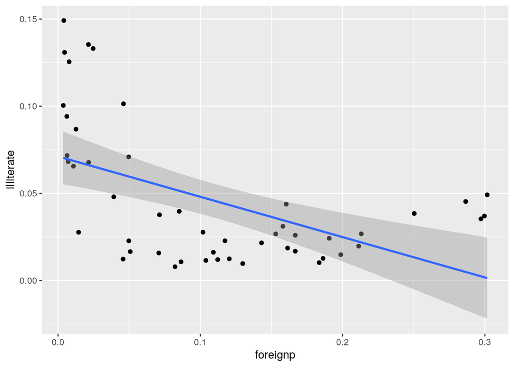

```r
illiteracy30 %>%
  mutate(foreignp = fbwhite/pop,
         illiterate = pop_il/pop,
         fbilliterate = fbwhite_il/fbwhite) %>%
  ggplot(.,aes(foreignp, illiterate)) + geom_point() +
  geom_smooth(method = "lm")
```

Why? Simple: immigrants were moving to places with lower illiteracy rates, which generally had more economic opportunity (e.g. NY, NJ) Basically, ecological correlations are not substitutes for individual correlations.

# Central Limit Theorem

Central limit theorem says:

1. with an infinite number samples of size n…
2. from a population of N units…
3. the sample means will be normally distributed
4. Further: the mean of sample means would equal the population mean
5. Random sampling error would equal the standard error of the sample means.

Let’s illustrate this with some thermometer rating data. This is Trump’s therm score from the ANES exploratory testing survey done April 10-18, 2020. I love thermometer data to teach central limit theorem because it shows the underlying principles, even in data that are noisy/ugly as hell. First, read more about the data and see it here. Just so we’re on the same page: higher values indicate “warmer” attitudes toward Trump (i.e. more favorable attitudes). Lower values indicate “colder” attitudes toward Trump (i.e. less favorable attitudes).

```r
?therms
therms
```

```
## # A tibble: 3,080 x 2
##    fttrump1 ftobama1
##       <dbl>    <dbl>
##  1       80       75
##  2       85       15
##  3       NA       NA
##  4       80       50
##  5        0      100
##  6       35        5
##  7       30       90
##  8       60       50
##  9        0       85
## 10        1       85
## # … with 3,070 more rows
```

Observe how ugly as hell the distribution of this variable is.

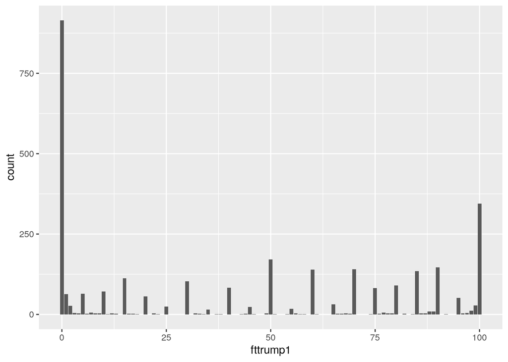

```r
therms %>%
  ggplot(.,aes(fttrump1)) + geom_bar()
```

These data are ugly, right? Even as the mean and median are not too far removed from each other, the large standard deviation on a bounded 0-100 scale suggests something is weird about the data (that you just saw).

```r
therms %>% select(fttrump1) %>%
  na.omit %>%
  summarize_all(list(mean = mean,
                     median = median,
                     sd = sd))
```

```
## # A tibble: 1 x 3
##    mean median    sd
##   <dbl>  <dbl> <dbl>
## 1  42.4     40  38.8
```

So let’s do something here. Let’s treat this therm score as the “population”. I.e. of 2500 or so observations, this constitutes the full universe of thermometer ratings for Donald Trump. Now, we we want to see if we can approximate it by sampling from it.

```r
therms %>%
  select(fttrump1) %>% na.omit %>%
  pull(fttrump1) -> Trump
```

Now check this shit out. First, let’s set a reproducible seed for sampling so you and I get the same samples back. PRO TIP: you should always set a reproducible seed for any simulation. It’s good practice for max reproducibility. We are going to take 1,000,000 samples of 10 observations from the data and report the means of them. Let’s be clear: no one should ever strive to have a random sample of 10 people. But we’re going for something here:

```r
set.seed(8675309) # Jenny, I got your number...
trumpsamples <- tibble(
  samplemean=sapply(1:1000000,
           function(i){ x <- mean(
             sample(Trump, 10,
                    replace = FALSE))
           }))
```

^ this might take a few seconds. You’re doing a million samples, after all. Let’s plot the distribution of our sample means. Here’s a histogram underneath a density function of the normal distribution with the parameters derived from the simulations.

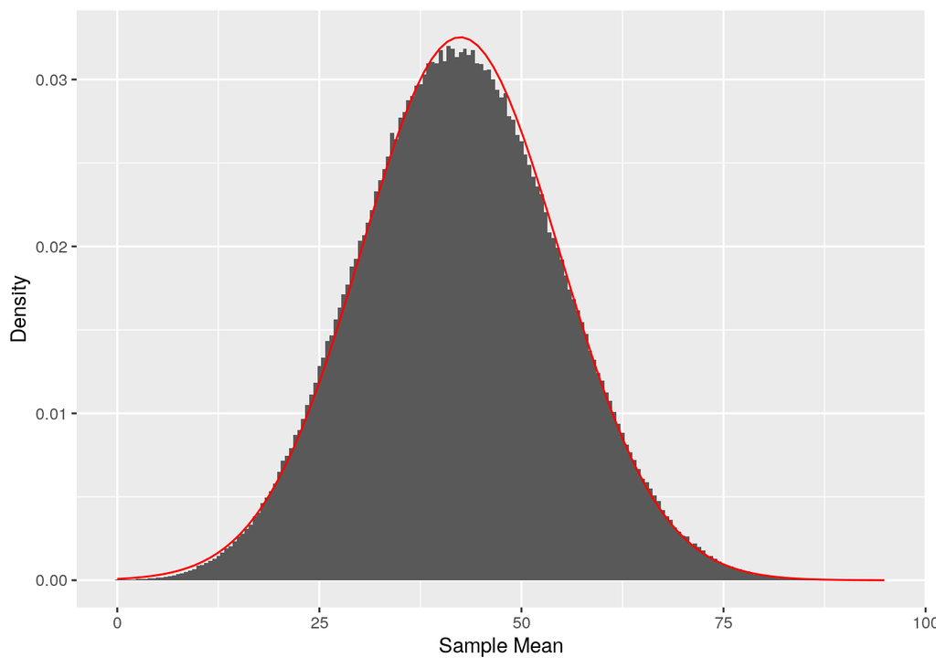

```r
trumpsamples %>%
  ggplot(.,aes(samplemean)) + geom_histogram(binwidth=.5,aes(y=..density..)) +
  stat_function(fun=dnorm,
                color="red",
                args=list(mean=mean(trumpsamples$samplemean),
                          sd=sd(trumpsamples$samplemean))) +
  xlab("Sample Mean") + ylab("Density")
```

Looks “normal”, right?

1. The tails are asymptote to zero. They approach it but don’t touch it.
2. The kernel inside the exponent is a basic parabola. The negative sign flips it downward.
3. It’s denoted as a function and not a probability because it is a continuous distribution. The probability of any one value is near zero.
4. The distribution is perfectly symmetrical. x is as far from mu as -x is from mu.
5. x is unrestricted. It can be any value.
6. mu defines the central tendency
7. sigma defines how short/wide the distribution is.
8. A special case occurs when mu is zero and sigma is 1. The formula becomes a lot simpler. I’ll belabor that bit later.

Anywho, how did we do?

```r
mean(Trump)
```

```
## [1] 42.41913
```

```r
mean(trumpsamples$samplemean)
```

```
## [1] 42.41954
```

Not bad. We were off by around 4/10000th of a point. A million is a lot, but not infinity after all. The principle that emerges is still clear.

Central limit theorem shows its ideal to take a shitload of samples to guess a population parameter from it. Sometimes, that’s not practical. You really can’t take infinity samples of the United States in a time-invariant way. So, there’s another way: get a good-sized random sample. If you understand random sampling error, you’ll know you can’t do much about the variation inherent in the population. In our case, these data are ugly as hell. What you can do, however, is reduce the sampling error by increasing the size of the sample.

Here’s how we’ll do it. We’re going to take 10 random samples of sizes 10, 100, 400, and 1000. Observe:

```r
moresamples = tibble()

set.seed(8675309) # Jenny, I got your number...
for(j in c(10, 100, 400, 1000)) {
  hold_this <- tibble(
    x= j,
    y=sapply(1:10,
             function(i){ x <- mean(
               sample(Trump, j,
                      replace = FALSE))
             }))
  moresamples <- bind_rows(moresamples, hold_this)
}
```

Now let’s look at the results. In the code below, each dot coincides with one of 10 sample means of a given sample size (10, 100, 400, and 1000). The dashed horizontal line communicates the actual population mean as we understand it.

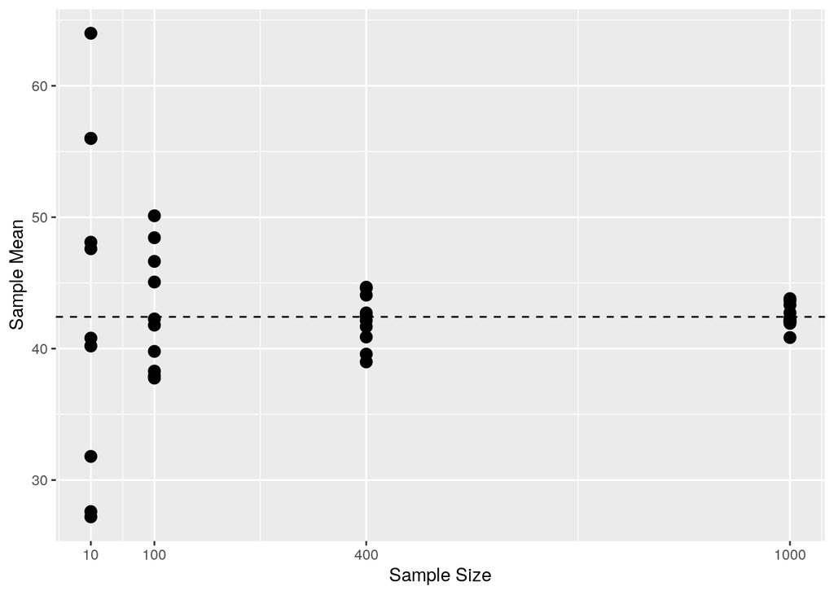

```r
moresamples %>%
  ggplot(.,aes(x, y)) + geom_point(size = 3) +
  scale_x_continuous(breaks = c(10, 100, 400, 1000)) +
  xlab("Sample Size") + ylab("Sample Mean") +
  geom_hline(aes(yintercept=mean(Trump)), linetype="dashed")
```

Here’s how you should interpret the plot above. Notice that 10 samples of 10 gets you results all over the place. This is unsurprising. We have a few samples. The sample size is small. The variation in the population is huge. We’re all over the place. Things start to get better at 100 and 400 samples. Notice how increasing the sample size increases the accuracy of the sample mean. They’re starting to bunch around the actual population mean. The 10 samples of size 1,000 are all hovering closely around the actual population mean. PRO TIP: survey researchers have learned that a national poll “sweet spot” is about 1000 respondents. Most polls you see are thereabouts in size. It’s a “bang for your buck” thing. Fewer than 1000 observations and your random sampling error starts to get appreciably bigger. Any more than that and, generally, you might find yourself careening into Literary Digest Poll territory. To be clear: others do some large-N surveys quite well, but increasing the sample size just to increase it does incentivize some non-random sampling. Plus, it’s more expensive and the “payout” from a larger sample size may not be worth the cost. It’s why you get that sweet spot you routinely observe from opinion polls.

I mentioned above that a special case of the normal distribution occurs when mu is zero and sigma is 1. It allows for an easier summary of the distribution and the areas underneath it. To reiterate: the probability of any one particular value is basically zero (since it’s continuous), but the area underneath the distribution constitutes the full domain and sums to 1. There are some set intervals around the mu that emerge in interesting ways. Observe where the cutoffs are for 68% of the distribution around the mean, 90%, 95%, and 99%.

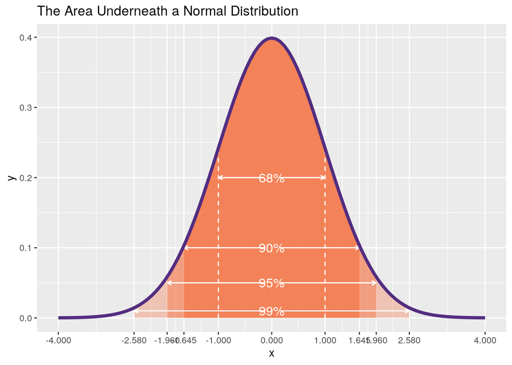

```r
# For ease, just use normal_dist() in {stevemisc}
ggplot(data.frame(x = c(-4, 4)), aes(x)) +
  stat_function(fun = dnorm,
                xlim = c(qnorm(.05),abs(qnorm(.05))), size=0,
                geom = "area", fill="#F66733", alpha=0.5) +
  stat_function(fun = dnorm,
                xlim = c(qnorm(.025),abs(qnorm(.025))), size=0,
                geom = "area", fill="#F66733", alpha=0.4) +
  stat_function(fun = dnorm,
                xlim = c(qnorm(.005),abs(qnorm(.005))), size=0,
                geom = "area", fill="#F66733", alpha=0.3) +
  geom_segment(x=1, y=0, xend=1, yend=dnorm(1,0,1), color="white", linetype="dashed") +
  geom_segment(x=-1, y=0, xend=-1, yend=dnorm(1,0,1), color="white", linetype="dashed") +
  annotate(geom = "text", x = 0, y = 0.2,
           label = "68%", size =4.5, color="white") +
  geom_segment(x=-0.15, y=.2, xend=-.99, yend=.2, color="white",
               arrow = arrow(length = unit(0.15, "cm"))) +
  geom_segment(x=0.15, y=.2, xend=.99, yend=.2, color="white",
               arrow = arrow(length = unit(0.15, "cm"))) +
  annotate(geom = "text", x = 0, y = 0.1,
           label = "90%", size =4.5, color="white") +
  geom_segment(x=-0.15, y=.1, xend=-1.64, yend=.1, color="white",
               arrow = arrow(length = unit(0.15, "cm"))) +
  geom_segment(x=0.15, y=.1, xend=1.64, yend=.1, color="white",
               arrow = arrow(length = unit(0.15, "cm"))) +
  annotate(geom = "text", x = 0, y = 0.05,
           label = "95%", size =4.5, color="white") +
  geom_segment(x=-0.15, y=.05, xend=-1.95, yend=.05, color="white",
               arrow = arrow(length = unit(0.15, "cm"))) +
  geom_segment(x=0.15, y=.05, xend=1.95, yend=.05, color="white",
               arrow = arrow(length = unit(0.15, "cm"))) +
  annotate(geom = "text", x = 0, y = 0.01,
           label = "99%", size =4.5, color="white") +
  geom_segment(x=-0.15, y=.01, xend=-2.57, yend=.01, color="white",
               arrow = arrow(length = unit(0.15, "cm"))) +
  geom_segment(x=0.15, y=.01, xend=2.57, yend=.01, color="white",
               arrow = arrow(length = unit(0.15, "cm"))) +
  stat_function(fun = dnorm, color="#522D80", size=1.5) +
  scale_x_continuous(breaks=c(-4, -2.58, -1.96, -1.645, -1, 0,
                              1, 1.645, 1.96, 2.58, 4)) +
  ggtitle("The Area Underneath a Normal Distribution")
```

It’s why standardization is useful, among other things. Standardization (where the mean is zero and the sd = 1) is easy to calculate.

```r
trumpsamples %>%
  mutate(z = (samplemean-mean(samplemean))/sd(samplemean)) -> trumpsamples
```